# Intro: Experiments and Causality

### A Motivating Example

As a result of trends in global migration, Western societies have become more ethnically diverse. Researchers are interested in whether these demographic shifts have also increased anti-immigrant prejudice.

Consider the following research design:

Prof. Axel uses data from a multi-country survey (e.g. Eurobarometer) containing a battery of questions on anti-immigration attitudes. The survey was conducted in 15 Western European countries in 2020. Approximately 1000 interviews were conducted in each country, and national samples are representative of the population aged 15 and over.

Axel merges the survey data to OECD data on GDP per capita and the percentage of immigrants in each country in 2019. He regresses anti-immigrant attitudes on the percentage of immigrants, controlling for GDPpc and the following individual-level variables:

- education
- age
- gender
- working class status
- income
- frequency of contact with members of other races / nationalities

**Class Questions:**

1. Suppose Axel finds that citizens from countries with more immigrants also express greater prejudice? Would you interpret this result as evidence of a *causal effect* of immigration on attitudes?
2. What about if, instead of measuring immigration at the national level, Axel were to use instead the percentage of foreigners in the respondents’ neighborhood? Would this make his results more convincing?

Consider now a somewhat more sophisticated study. Social scientists hypothesize that immigration is most likely to arouse controversy in traditionally ethnically “homogenous” areas that see a rapid increase in diversity levels.

To test this idea, Prof. Barker manages to get her hands on panel data where the same respondents are surveyed repeated only multiple years. Barker also manages to obtain administrative data on the percentage of foreigners in the respondents’s neighborhood for each year of the survey.

Barker focuses her attention on those respondents living in ethnically homogenous areas at time 0. When re-surveyed at time 1, some of these respondents (let’s call them group A) were still living in homogenous areas. However, other respondents (let’s call them group B) were living in more diverse neighborhoods.

Since she has panel data, Barker is able to look at *within-person* changes in prejudice. Her analysis asks whether people in group B became more prejudiced over time, relative to people in group A.

**Class Questions:**

3. Suppose Barker finds that people in group B did indeed become more prejudiced relative to people in group A. Are you now convinced that immigration exerts a causal effect on attitudes?
4. Compare these **observational studies** against an [experimental design](https://nanzhangresearch.github.io/enos_excerpt.pdf). What are the main differences between the two methodologies?

### Randomization and Causality

In experiments, the credibility of causal claims is not based on whether the model includes the “right” controls (or has the “right” functional form).

Rather, evidence of causality rests on the **procedure** by which individuals / units are sorted into treatment and control groups.

**Random assignment** implies that any (observed and unobserved) factors that affect outcomes are (on average) equally likely to be present in the treatment and control groups. Thus the treatment itself is the only systematic driver of differences in outcomes.

**Example Balance Table**

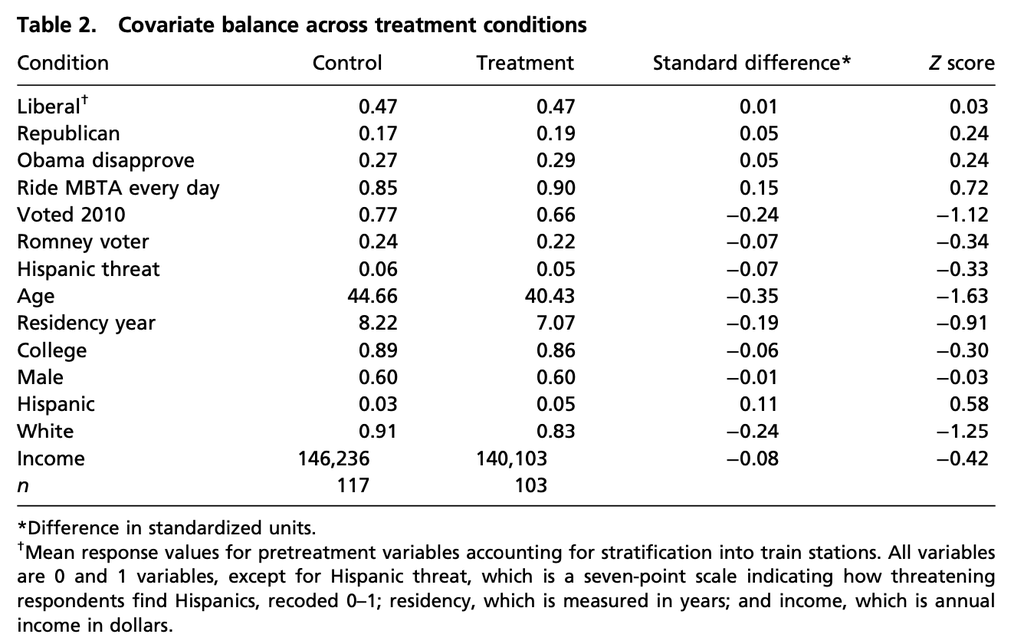

**Class Question:**

5. Many programs strive to help students prepare for college entrance exams, such as the SAT. In an effort to study the effectiveness of these preparatory programs, a researcher draws a random sample of students attending public high school in the United States, and compares the SAT scores of those who took a preparatory class to those who did not. **Is this an experiment or an observational study?**

### Field Experiments

Field experiments combine randomization with:

- naturalist / authentic interventions
- attention to realistic outcomes and consequential behaviors
- (possibly) unobtrusive measurement
- diverse “real-world” samples and settings

These features set field experiments apart from survey and lab experiments.

Additionally, these features may be consequetial for the inferences that researchers draw.

**Discrimination Example**

In the context of labor market discrimination, researchers are often interested in whether minority job applicants are less likely to be hired than (equally qualified) majority applicants.

To answer this question, imagine that some researchers create CVs for two fictitious job applicants. The CVs are identical, except that one applicant is named “Connor Williams” while the other is named “Deshaun Williams”.

Compare the following two experimental approaches:

**A.** Researchers recruit a sample of HR managers to participate in a survey experiment. Each HR manager is asked to evaluate one of the two CVs (randomly selected), and then indicate whether they would invite this person to interview for a job opening at their firm. Researchers compare the percentage of positive responses elicited by “Connor” vs “Deshaun.”

**B.** Researchers compile a list of job openings from jobs.com, and send one (randomly selected) CV to each job advertisement. Researchers then compare the number of callbacks elicited by “Connor” vs “Deshaun.”

**Political Information Example**

Recent increases in political polarization have been linked to the rise of (online) “echo chambers”, wherein individuals only seek out political information that confirms their pre-existing views.

Against this backdrop, some researchers want to find out whether exposing individuals to countervailing political information can reduce polarization.

Compare the following two experimental designs:

**A.** Researchers identify a sample of conservative voters from public records. These individuals are invited to take part in an online survey. Survey respondents are randomly divided into treatment and control groups. Respondents in the treatment group are asked to read a series of news articles from a liberal media outlet, before answering a series of questions about their political attitudes. Respondents in the control group are asked to simply answer the political attitude questions.

**B.** Researchers identify a sample of conservative voters from public records. This is sample is randomly divided into treatment and control groups. Households in the treatment group are sent a free subscription to a liberal newspaper for one month. At the end of the month, researchers conduct an online survey measuring political attitudes.

**Class Questions:**

6. Which design would yield larger treatment effects? Why?
7. Which design do you find more convincing?

Field experiments can also play diverse roles within the context of a larger line of research.

Field experiments often come in the form of randomized control trials (RCTs), which evaluate the effectiveness of a particular policy. Such studies are common in development economics, but also consider A/B testing:

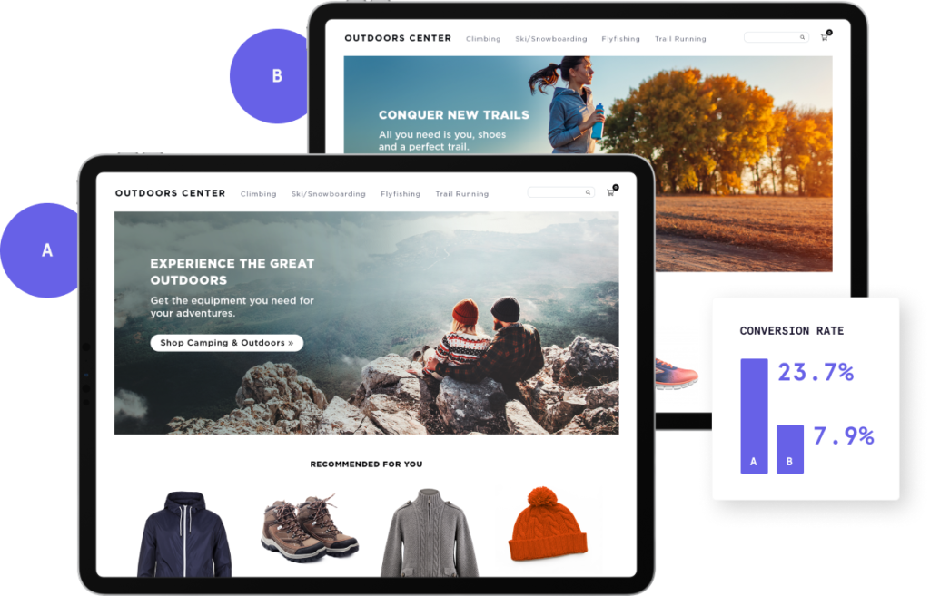

RCTs are often criticized for being atheoretical. That is, we know that intervention X has Y effect in context Z, but we don’t know why, and we don’t know whether the result generalizes to other people and places.

At the other end of the spectrum, some field experiments have been designed as behavioral tests of basic theory. See this [study](https://www.npr.org/2019/06/20/734141432/what-dropping-17-000-wallets-around-the-globe-can-teach-us-about-honesty).

[Here](https://journals.sagepub.com/doi/pdf/10.1111/j.1467-9280.2007.01917.x)’s a good example of a (short) study that uses social norms theory to inform the design of policies to reduce household energy consumption. The resulting field experiment constitutes both an evaluation of programme effectiveness as well as a “test” of the underlying theory.

### Potential Outcomes

Going back to our SAT example, what does it mean to say that college prep courses have a causal effect on SAT scores?

| Illustration of potential outcomes, depending on whether an individual takes a prep course | Illustration of potential outcomes, depending on whether an individual takes a prep course SAT if no prep | Illustration of potential outcomes, depending on whether an individual takes a prep course SAT if prep | Illustration of potential outcomes, depending on whether an individual takes a prep course Difference |
| --- | --- | --- | --- |
| Alex | 650 | 670 | 20 |
| Bonnie | 500 | 580 | 80 |
| Colin | 550 | 550 | 0 |
| Danielle | 700 | 690 | -10 |
| Earl | 600 | 660 | 60 |
| Fiona | 650 | 720 | 70 |
| Gaston | 400 | 580 | 180 |
| Hermine | 750 | 750 | 0 |
| AVERAGE | 600 | 650 | 50 |

To say that prep courses **cause** an increase in SAT scores, we mean that *in an imaginary counterfactual world* where the people who didn’t take the prep course *had* actually taken the course, then their SAT scores would be 50 points higher, on average.

This is the idea behind **causation** within the **potential outcomes framework**.

*If* we could observe everyone’s potential outcome (as in the above table), then finding evidence of causation is easy! We would even be able to identify the causal effect for each individual.

Of course, we **cannot** observe these counterfactual worlds. In the real world, people either attend the prep course, or they didn’t. In other words, our real-world data look something like this:

| Illustration of potential outcomes, depending on whether an individual takes a prep course | Illustration of potential outcomes, depending on whether an individual takes a prep course SAT if no prep | Illustration of potential outcomes, depending on whether an individual takes a prep course SAT if prep | Illustration of potential outcomes, depending on whether an individual takes a prep course Difference |
| --- | --- | --- | --- |
| Alex | ? | 670 | ? |
| Bonnie | 500 | ? | ? |
| Colin | 550 | ? | ? |
| Danielle | ? | 690 | ? |
| Earl | 600 | ? | ? |
| Fiona | ? | 720 | ? |
| Gaston | 400 | ? | ? |
| Hermine | ? | 750 | ? |

Since we do not observe counterfactual outcomes, we cannot estimate a separate treatment effect for each individual.

But with random assignment, we can estimate an **average treatment effect** (ATE) for the population.

Suppose we have a population N=1000.

We randomly assign 500 of them to take the prep course (and they actually attend all sessions). Let’s call these people the **treatment group (T)**, and let’s call their SAT scores **treatment outcomes.**

The other 500 people who do not attend the prep course constitute the **control group (C)**. Their SAT scores constitute the **control outcomes.**

**Class Questions:**

8. Suppose that the average of the *observed* treatment outcomes = 650. What is your estimate of the average of all of the *potential* treatment outcomes?
9. Similarly, suppose that the average of the *observed* control outcomes = 600. What is your estimate of the average of all of the *potential* control outcomes?

**Key Takeaway**

Since you have randomly assigned people to **T** and **C**, you can think of the **observed outcomes** as a random sample of *all potential* outcomes.

By implication, the average observed outcomes constitute an unbiased estimate of the average potential outcomes.

Thus the average difference in observed outcomes constitutes an unbiased **causal** estimate of the ATE.

### Selection Bias without Random Assignment

| Consider this table again, in comparison to the full schedule of potential outcomes | Consider this table again, in comparison to the full schedule of potential outcomes Potential C | Consider this table again, in comparison to the full schedule of potential outcomes Potential T | Consider this table again, in comparison to the full schedule of potential outcomes Observed C | Consider this table again, in comparison to the full schedule of potential outcomes Observed T |
| --- | --- | --- | --- | --- |
| Alex | 650 | 670 | ? | 670 |
| Bonnie | 500 | 580 | 500 | ? |
| Colin | 550 | 550 | 550 | ? |
| Danielle | 700 | 690 | ? | 690 |
| Earl | 600 | 660 | 600 | ? |
| Fiona | 650 | 720 | ? | 720 |
| Gaston | 400 | 580 | 400 | ? |
| Hermine | 750 | 750 | ? | 750 |
| AVERAGE | 600 | 650 | 512.5 | 707.5 |

**Class Questions:**

10. Here, the difference in average treatment and control outcomes is 195, which is much larger than the ATE of 50. Looking at the full schedule of potential outcomes, can you figure out why?
11. Suppose that we obtain these results from an observational study, where subjects themselves choose whether they want to take part in the prep class. Why is this problematic?
12. Suppose instead that our randomization procedure just happened to assign Alex, Danielle, Fiona and Hermine to treatment. Is our estimate of the ATE biased?

**Key Takeaway**

Unbiasedness is a property of the estimation procedure, not of a single estimate.

If we allow people to self-select in T and C, we can no longer consider the observed treatment/control outcomes as a random sample of all potential treatment/control outcomes. Thus, our basis for assessing causality falls apart.

In the absence of random assignment, estimates of the ATE may be **biased** (here: *ability* is a confounding variable).

Randomization solves this problem by making sure that potential outcomes are, **on average**, statistically independent of the treatments that subjects receive.

In other words, **on average**, ability (plus all other possible confounding variables) is equalized between T and C.

Even though, in this single experiment, people in T had higher ability, these differences should cancel out over repeated experiments. As long as the randomization procedure is followed correctly, then the experiment yields an unbiased estimate of the ATE.

**Another example:** a researcher wants to know how winning large sums of money in a national lottery affects peoples views about inheritance taxes. The researcher interviews a random sample of adults and compares the attitudes of those who report winning more than $10,000 in the lottery to those who claim to have won little or nothing. The researcher reasons that the lottery chooses winners at random, and therefore the amount that people report having won is random.

**Class Questions:**

13. Is this sound reasoning? In other words, are the potential outcomes of those who report winning more than $10,000 identical, in expectation, to those who report winning little or nothing?
14. Suppose the researcher were to restrict the sample to people who had played the lottery at least once during the past year. Is it now safe to assume that the potential outcomes of those who report winning more than $10,000 are identical, in expectation, to those who report winning little or nothing?

### Assumptions

**Excludability**

Potential outcomes respond solely to receipt of the treatment, not to the assignment itself or any indirect by-products of the assignment.

Here’s an example. Suppose you want to test the effectiveness of a new medication. You recruit a sample of people who are interested in the medication, and randomly divide them into treatment and control groups.

The treatment group is asked to take the medication in the form of a pill. The control group is told that their purpose is to serve as comparison group, and thus will not be receiving the medication.

Two research assistants – Karl and Lenny – are in charge of conducting the study. Lenny measures outcomes for the control group, while Karl measures outcomes from the treatment group.

**Class Question:**

15. How might this design violate the excludability assumption?

Here’s another example. Suppose researchers seek to assess the effect of receiving a free newspaper subscription on students’ interest in politics. A list of student dorm rooms is drawn up and sorted randomly. Dorm rooms in the first half of the randomly sorted list receive a newspaper at their door each morning for two months; dorm rooms in the second half of the list do not receive a paper.

University researchers are sometimes required to disclose to subjects that they are participating in an experiment. Suppose that prior to the experiment, researchers distributed a letter informing students in the treatment group that they would be receiving a newspaper as part of a study to see if newspapers make students more interested in politics.

**Class Question:**

16. How might this disclosure jeopardize the excludability assumption?

**Non-interference (SUTVA)**

Potential outcomes for each individual reflect only the treatment or control status of that individual and not the treatment or control status of other individuals. No matter which subjects the random assignment allocates to treatment or control, a given subject’s potential outcomes remain the same.

This idea is commonly termed the **stable unit treatment value assumption** (SUTVA).

| Here is a schedule of potential outcomes containing a SUTVA violation | Here is a schedule of potential outcomes containing a SUTVA violation Aly C, Bob C | Here is a schedule of potential outcomes containing a SUTVA violation Aly C, Bob T | Here is a schedule of potential outcomes containing a SUTVA violation Aly T, Bob C | Here is a schedule of potential outcomes containing a SUTVA violation Aly T, Bob T |
| --- | --- | --- | --- | --- |
| Aly | 650 | 650 | 670 | 670 |
| Bob | 500 | 520 | 580 | 600 |

A researcher studying 1,000 prison inmates noticed that prisoners who spend at least three hours per day reading are less likely to have violent encounters with other prisoners. The researcher therefore recommends that all prisoners be required to spend at least three hours reading each day.

Suppose that researchers were to test this researchers hypothesis by randomly assigning 10 prisoners to a treatment group. Prisoners in this group are required to go to the prison library and read in specially designated carrels for three hours each day for one week; the other prisoners, who make up the control group, go about their usual routines.

**Class Questions:**

17. Can you state the non-interference assumption as it applies to this experiment? Do you think this assumption is met?
18. Now let’s modify the design a bit. Suppose that every day, researchers toss a coin. If heads, then all prisoners go about their usual routines. If tails, then all prisoners are assigned to read for 3 hours in the library. The researchers the compare the average number of violent encounters on “normal days” vs “library days”. Does this solve the SUTVA problem?

### Upcoming topics

- Sampling distributions and uncertainty surronding the ATE
- Blocking
- Pre-post designs
- Hypothesis testing via randomization inference
- Power calculations